# Chess Games Exploration

Isaias Bastidas

05-01-2021

# Introduction

Chess is a puzzle game where you can compete one-on-one with your opponent. In general, it can become harshly competitive and fun enough where other people will be motivated to play this game. This examination is about how each of the player’s position affects their performance and which class are they played best.

Example:

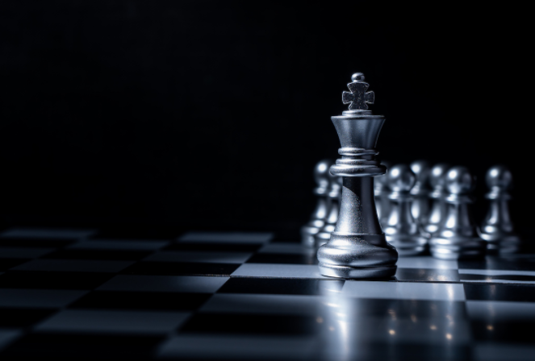

## Link to your data

The R project webpage, all found in kaggle: https://www.kaggle.com/arevel/chess-games

## Questions/ Reasons

If you are a chess player, will you face end up in either a normal termination or penalties? Which side (“Black or White”) tends to have its skill rate or rating difference to reach to its own termination? Does this also depend if you are an experienced chess player or not?

# Packages

All packages utilized:

```r
library(dplyr) #this package is used for data manipulation
```

```r
library(ggplot2) #this package to refine the visualizations
library(ROCR)#this package is required to use a function to measure thresholds
library(caTools)#this package helps me to handle predictions
library(stringr)#this package is crucial for replacement
```

# reading the data

include a chunk to read the data and names

```r
chessGames <- read.csv("chess_games.csv", header = TRUE, as.is = TRUE)
names(chessGames)
```

```
##  [1] "Event"           "White"           "Black"           "Result"
##  [5] "UTCDate"         "UTCTime"         "WhiteElo"        "BlackElo"
##  [9] "WhiteRatingDiff" "BlackRatingDiff" "ECO"             "Opening"
## [13] "TimeControl"     "Termination"     "AN"
```

# Data Explorations

```r
head(chessGames)
```

```
##                Event           White      Black Result    UTCDate  UTCTime
## 1         Classical          eisaaaa   HAMID449    1-0 2016.06.30 22:00:01
## 2             Blitz           go4jas Sergei1973    0-1 2016.06.30 22:00:01
## 3  Blitz tournament  Evangelistaizac     kafune    1-0 2016.06.30 22:00:02
## 4    Correspondence           Jvayne   Wsjvayne    1-0 2016.06.30 22:00:02
## 5  Blitz tournament           kyoday  BrettDale    0-1 2016.06.30 22:00:02
## 6  Blitz tournament   lucaseixasouza     diguim    0-1 2016.06.30 22:00:02
##   WhiteElo BlackElo WhiteRatingDiff BlackRatingDiff ECO
## 1     1901     1896              11             -11 D10
## 2     1641     1627             -11              12 C20
## 3     1647     1688              13             -13 B01
## 4     1706     1317              27             -25 A00
## 5     1945     1900             -14              13 B90
## 6     1773     1809             -10              10 C27
##                                         Opening TimeControl  Termination
## 1                                  Slav Defense       300+5 Time forfeit
## 2                     King's Pawn Opening: 2.b3       300+0       Normal
## 3 Scandinavian Defense: Mieses-Kotroc Variation       180+0 Time forfeit
## 4                          Van't Kruijs Opening           -       Normal
## 5   Sicilian Defense: Najdorf, Lipnitsky Attack       180+0 Time forfeit
## 6                                   Vienna Game       180+0       Normal
##                                                                                                                                                                                                                                                                                                          …
## 1                                                                                                                                                                                  1. d4 d5 2. c4 c6 3. e3 a6 4. Nf3 e5 5. cxd5 e4 6. Ne5 cxd5 7. Qa4+ Bd7 8. Nxd7 Nxd7 9. Nc3 Nf6 10. Qb3 Be7 11. Nxd5 Q…
## 2                                                                                                                                                                                                                                                                                                        …
## 3                                                                                                                                                                                                                                                           1. e4 d5 2. exd5 Qxd5 3. Nf3 Bg4 4. Be2 Nf6 5…
## 4                                                                                                                                                                                                                                                           1. e3 Nf6 2. Bc4 d6 3. e4 e6 4. Nf3 Nxe4 5. N…
## 5 1. e4 c5 2. Nf3 d6 3. d4 cxd4 4. Nxd4 Nf6 5. Nc3 a6 6. Bc4 Qc7 7. Bb3 b5 8. O-O Bb7 9. Re1 Nbd7 10. Be3 g6 11. f3 Bg7 12. Qe2 O-O 13. Rad1 b4 14. Na4 a5 15. Qf2 Rfc8 16. Ne2 Qd8 17. Bb6 Qe8 18. Be3 Ra6 19. c4 Nh5 20. Ng3 Nxg3 21. hxg3 Bc6 22. Qd2 Be5 23. Kf2 Ba8 24. Bd4 Rac6 25. f4 Bf6 26. g4 N…
## 6                                                                                                       1. e4 e5 2. Nc3 d6 3. Nf3 h6 4. Bc4 c6 5. b3 Qf6 6. Bb2 b5 7. Be2 Be6 8. d4 Be7 9. dxe5 dxe5 10. Qd2 Nd7 11. O-O-O Rd8 12. Bd3 a5 13. Ne2 b4 14. h4 g5 15. hxg5 hxg5 16. Rxh8 Qxh8 17. Nxg5 Bf8 1…
```

Show the size of the data

```r
object.size(chessGames)
```

```
## 4626300200 bytes
```

numbers of rows and columns

```r
paste(nrow(chessGames),"rows")
```

```
## [1] "6256184 rows"
```

```r
paste(ncol(chessGames),"columns")
```

```
## [1] "15 columns"
```

classes of columns, how many `NA`?

```r
str(chessGames)
```

```
## 'data.frame':    6256184 obs. of  15 variables:
##  $ Event          : chr  " Classical " " Blitz " " Blitz tournament " " Correspondence " ...
##  $ White          : chr  "eisaaaa" "go4jas" "Evangelistaizac" "Jvayne" ...
##  $ Black          : chr  "HAMID449" "Sergei1973" "kafune" "Wsjvayne" ...
##  $ Result         : chr  "1-0" "0-1" "1-0" "1-0" ...
##  $ UTCDate        : chr  "2016.06.30" "2016.06.30" "2016.06.30" "2016.06.30" ...
##  $ UTCTime        : chr  "22:00:01" "22:00:01" "22:00:02" "22:00:02" ...
##  $ WhiteElo       : int  1901 1641 1647 1706 1945 1773 1895 2155 2010 1764 ...
##  $ BlackElo       : int  1896 1627 1688 1317 1900 1809 1886 2356 2111 1773 ...
##  $ WhiteRatingDiff: num  11 -11 13 27 -14 -10 -12 20 -9 12 ...
##  $ BlackRatingDiff: num  -11 12 -13 -25 13 10 12 -20 9 -12 ...
##  $ ECO            : chr  "D10" "C20" "B01" "A00" ...
##  $ Opening        : chr  "Slav Defense" "King's Pawn Opening: 2.b3" "Scandinavian Defense: Mieses-Kotroc Variation" "Van't Kruijs Opening" ...
##  $ TimeControl    : chr  "300+5" "300+0" "180+0" "-" ...
##  $ Termination    : chr  "Time forfeit" "Normal" "Time forfeit" "Normal" ...
##  $ AN             : chr  "1. d4 d5 2. c4 c6 3. e3 a6 4. Nf3 e5 5. cxd5 e4 6. Ne5 cxd5 7. Qa4+ Bd7 8. Nxd7 Nxd7 9. Nc3 Nf6 10. Qb3 Be7 11."| __truncated__ "1. e4 e5 2. b3 Nf6 3. Bb2 Nc6 4. Nf3 d6 5. d3 g6 6. Nbd2 Bg7 7. g3 Be6 8. Bg2 Qd7 9. O-O O-O 10. c3 b5 11. d4 e"| __truncated__ "1. e4 d5 2. e…
```

```r
sapply(chessGames, anyNA)
```

```
##           Event           White           Black          Result         UTCDate
##           FALSE           FALSE           FALSE           FALSE           FALSE
##         UTCTime        WhiteElo        BlackElo WhiteRatingDiff BlackRatingDiff
##           FALSE           FALSE           FALSE            TRUE            TRUE
##             ECO         Opening     TimeControl     Termination              AN
##           FALSE           FALSE           FALSE           FALSE           FALSE
```

```r
sum(is.na(chessGames$WhiteRatingDiff))
```

```
## [1] 4668
```

```r
sum(is.na(chessGames$BlackRatingDiff))
```

```
## [1] 4668
```

Print out few lines

```r
table(chessGames$Termination)
```

```
##
##        Abandoned           Normal Rules infraction     Time forfeit
##            14630          4230089              128          2011336
##     Unterminated
##                1
```

Any substetting?

```r
chessGames2 = chessGames %>% select(-c(6,13,15))
write.csv(chessGames2, file = "updateChessGame.csv", row.names = FALSE)
```

Rename variables of interest if their original name is long

```r
chessTags = colnames(chessGames2)
chessTags
```

```
##  [1] "Event"           "White"           "Black"           "Result"
##  [5] "UTCDate"         "WhiteElo"        "BlackElo"        "WhiteRatingDiff"
##  [9] "BlackRatingDiff" "ECO"             "Opening"         "Termination"
```

```r
chessTags = chessTags %>%
  str_replace("UTCDate", "Date") %>%
  str_replace("WhiteElo", "WhiteEloRate") %>%
  str_replace("BlackElo", "BlackEloRate") %>%
  str_replace("WhiteRatingDiff", "WhiteRatingDifference") %>%
  str_replace("BlackRatingDiff", "BlackRatingDifference")
colnames(chessGames2) = chessTags
head(chessGames2)
```

```
##                Event           White      Black Result       Date WhiteEloRate
## 1         Classical          eisaaaa   HAMID449    1-0 2016.06.30         1901
## 2             Blitz           go4jas Sergei1973    0-1 2016.06.30         1641
## 3  Blitz tournament  Evangelistaizac     kafune    1-0 2016.06.30         1647
## 4    Correspondence           Jvayne   Wsjvayne    1-0 2016.06.30         1706
## 5  Blitz tournament           kyoday  BrettDale    0-1 2016.06.30         1945
## 6  Blitz tournament   lucaseixasouza     diguim    0-1 2016.06.30         1773
##   BlackEloRate WhiteRatingDifference BlackRatingDifference ECO
## 1         1896                    11                   -11 D10
## 2         1627                   -11                    12 C20
## 3         1688                    13                   -13 B01
## 4         1317                    27                   -25 A00
## 5         1900                   -14                    13 B90
## 6         1809                   -10                    10 C27
##                                         Opening  Termination
## 1                                  Slav Defense Time forfeit
## 2                     King's Pawn Opening: 2.b3       Normal
## 3 Scandinavian Defense: Mieses-Kotroc Variation Time forfeit
## 4                          Van't Kruijs Opening       Normal
## 5   Sicilian Defense: Najdorf, Lipnitsky Attack Time forfeit
## 6                                   Vienna Game       Normal
```

Include str and summary if possible

```r
str(chessGames2)
```

```
## 'data.frame':    6256184 obs. of  12 variables:
##  $ Event                : chr  " Classical " " Blitz " " Blitz tournament " " Correspondence " ...
##  $ White                : chr  "eisaaaa" "go4jas" "Evangelistaizac" "Jvayne" ...
##  $ Black                : chr  "HAMID449" "Sergei1973" "kafune" "Wsjvayne" ...
##  $ Result               : chr  "1-0" "0-1" "1-0" "1-0" ...
##  $ Date                 : chr  "2016.06.30" "2016.06.30" "2016.06.30" "2016.06.30" ...
##  $ WhiteEloRate         : int  1901 1641 1647 1706 1945 1773 1895 2155 2010 1764 ...
##  $ BlackEloRate         : int  1896 1627 1688 1317 1900 1809 1886 2356 2111 1773 ...
##  $ WhiteRatingDifference: num  11 -11 13 27 -14 -10 -12 20 -9 12 ...
##  $ BlackRatingDifference: num  -11 12 -13 -25 13 10 12 -20 9 -12 ...
##  $ ECO                  : chr  "D10" "C20" "B01" "A00" ...
##  $ Opening              : chr  "Slav Defense" "King's Pawn Opening: 2.b3" "Scandinavian Defense: Mieses-Kotroc Variation" "Van't Kruijs Opening" ...
##  $ Termination          : chr  "Time forfeit" "Normal" "Time forfeit" "Normal" ...
```

```r
summary(chessGames2)
```

```
##     Event              White              Black              Result
##  Length:6256184     Length:6256184     Length:6256184     Length:6256184
##  Class :character   Class :character   Class :character   Class :character
##  Mode  :character   Mode  :character   Mode  :character   Mode  :character
##
##
##
##
##      Date            WhiteEloRate   BlackEloRate  WhiteRatingDifference
##  Length:6256184     Min.   : 737   Min.   : 728   Min.   :-595.00
##  Class :character   1st Qu.:1559   1st Qu.:1557   1st Qu.:  -9.00
##  Mode  :character   Median :1740   Median :1739   Median :   1.00
##                     Mean   :1742   Mean   :1740   Mean   :   0.58
##                     3rd Qu.:1919   3rd Qu.:1919   3rd Qu.:  10.00
##                     Max.   :3110   Max.   :3108   Max.   : 673.00
##                                                   NA's   :4668
##  BlackRatingDifference     ECO              Opening          Termination
##  Min.   :-653.000      Length:6256184     Length:6256184     Length:6256184
##  1st Qu.: -10.000      Class :character   Class :character   Class :character
##  Median :  -1.000      Mode  :character   Mode  :character   Mode  :character
##  Mean   :  -0.368
##  3rd Qu.:   9.000
##  Max.   : 664.000
##  NA's   :4668
```

# Visualizations

```r
table(chessGames2$Result)
```

```
##
##       *     0-1     1-0 1/2-1/2
##    1343 2902394 3113572  238875
```

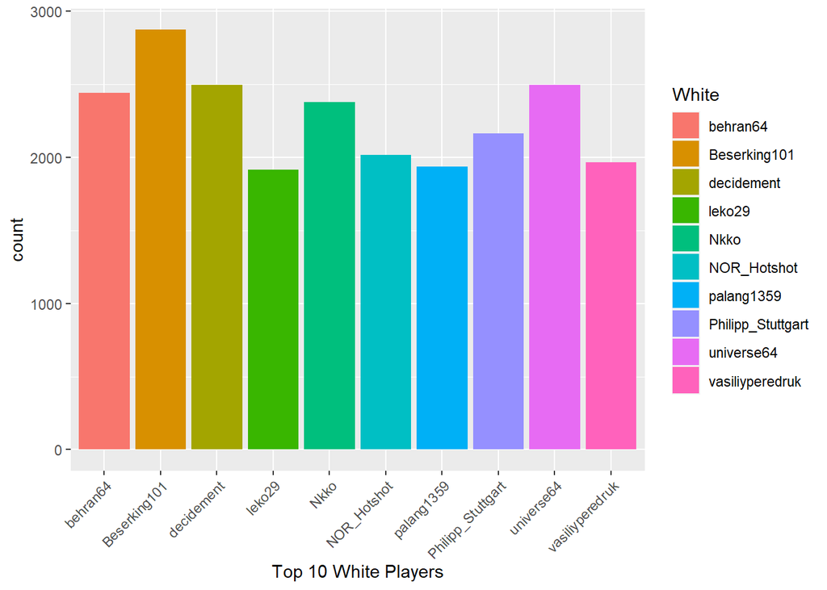

```r
reorder_size <- function(x) {
        factor(x, levels = names(sort(table(x), decreasing = TRUE)[1:10]))
}


chessGames2 %>%
   filter(!is.na(reorder_size(White))) %>%
     ggplot(aes(x= White, fill=White)) +
        geom_bar() +xlab("Top 10 White Players")+
  theme(axis.text.x = element_text(angle = 45, hjust = 1))
```

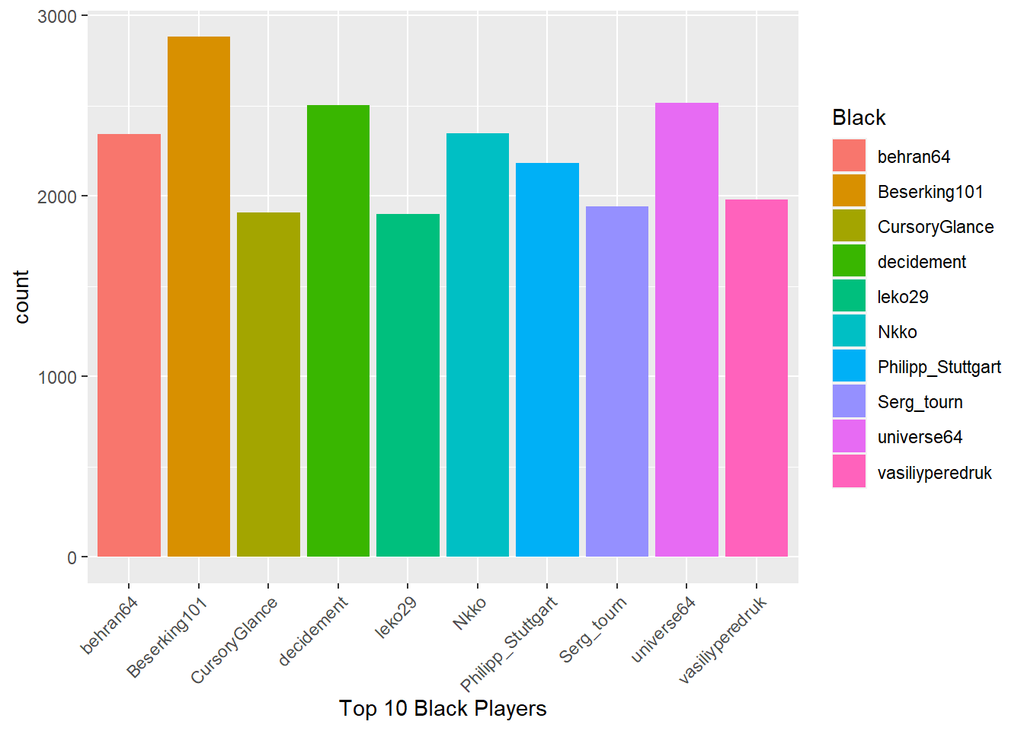

```r
chessGames2 %>%
   filter(!is.na(reorder_size(Black))) %>%
     ggplot(aes(x= Black, fill=Black)) +
        geom_bar() + xlab("Top 10 Black Players")+
  theme(axis.text.x = element_text(angle = 45, hjust = 1))
```

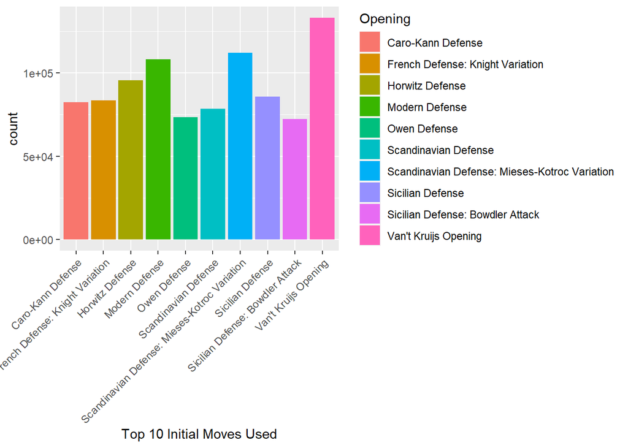

```r
chessGames2 %>%
   filter(!is.na(reorder_size(Opening))) %>%
     ggplot(aes(x= Opening, fill=Opening)) +
        geom_bar() +xlab("Top 10 Initial Moves Used")+
  theme(axis.text.x = element_text(angle = 45, hjust = 1))
```

```r
skillCheckWhite1 = ifelse(chessGames2$WhiteEloRate < 1000, "Newcomer",
                  ifelse(chessGames2$WhiteEloRate < 1200, "Class E",
                  ifelse(chessGames2$WhiteEloRate < 1400, "Class D",
                  ifelse(chessGames2$WhiteEloRate < 1600, "Class C",
                  ifelse(chessGames2$WhiteEloRate < 1800, "Class B",
                  ifelse(chessGames2$WhiteEloRate < 2000, "Class A",
                  ifelse(chessGames2$WhiteEloRate < 2200, "Expert",
                  ifelse(chessGames2$WhiteEloRate > 2400, "Senior Master","Master"))))))))

skillCheckWhite2 = factor(skillCheckWhite1,
              levels = c("Newcomer","Class E","Class D", "Class C", "Class B", "Class A", "Expert", "Master", "Senior Master"))
head(skillCheckWhite1)
```

```
## [1] "Class A" "Class B" "Class B" "Class B" "Class A" "Class B"
```

```r
table(skillCheckWhite2)
```

```
## skillCheckWhite2
##      Newcomer       Class E       Class D       Class C       Class B
##         10882        107803        487448       1270703       1803131
##       Class A        Expert        Master Senior Master
##       1552022        745698        225171         53326
```

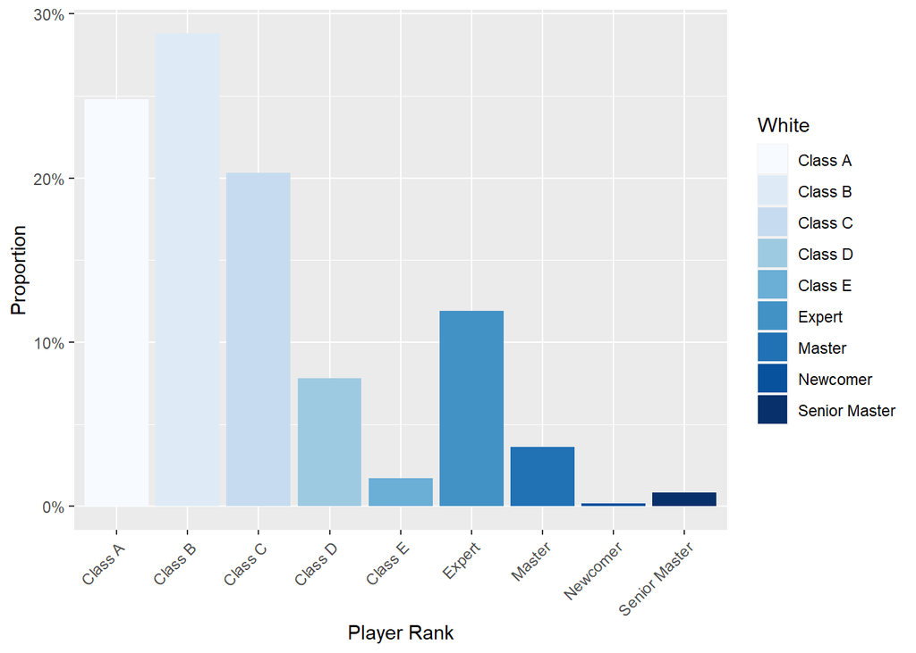

```r
chessGamesSKW <- chessGames2 %>% mutate(WhiteSkillLevel = skillCheckWhite1)

ggplot(chessGamesSKW, aes(x = WhiteSkillLevel, fill = WhiteSkillLevel)) +
        geom_bar(aes(y = (..count..)/sum(..count..))) +
        xlab("Player Rank") +
        scale_y_continuous(labels = scales::percent, name = "Proportion") +
        theme(axis.text.x = element_text(angle = 45, hjust = 1))+scale_fill_brewer("White")
```

```r
skillCheckBlack1 = ifelse(chessGames2$BlackEloRate < 1000, "Newcomer",
                  ifelse(chessGames2$BlackEloRate < 1200, "Class E",
                  ifelse(chessGames2$BlackEloRate < 1400, "Class D",
                  ifelse(chessGames2$BlackEloRate < 1600, "Class C",
                  ifelse(chessGames2$BlackEloRate < 1800, "Class B",
                  ifelse(chessGames2$BlackEloRate < 2000, "Class A",
                  ifelse(chessGames2$BlackEloRate < 2200, "Expert",
                  ifelse(chessGames2$BlackEloRate >= 2400, "Senior Master","Master"))))))))

skillCheckBlack2 = factor(skillCheckBlack1,
              levels = c("Newcomer","Class E","Class D", "Class C", "Class B", "Class A", "Expert", "Master", "Senior Master"))
head(skillCheckBlack1)
```

```
## [1] "Class A" "Class B" "Class B" "Class D" "Class A" "Class A"
```

```r
table(skillCheckBlack2)
```

```
## skillCheckBlack2
##      Newcomer       Class E       Class D       Class C       Class B
##         11139        111055        499941       1270253       1801193
##       Class A        Expert        Master Senior Master
##       1539437        743329        225758         54079
```

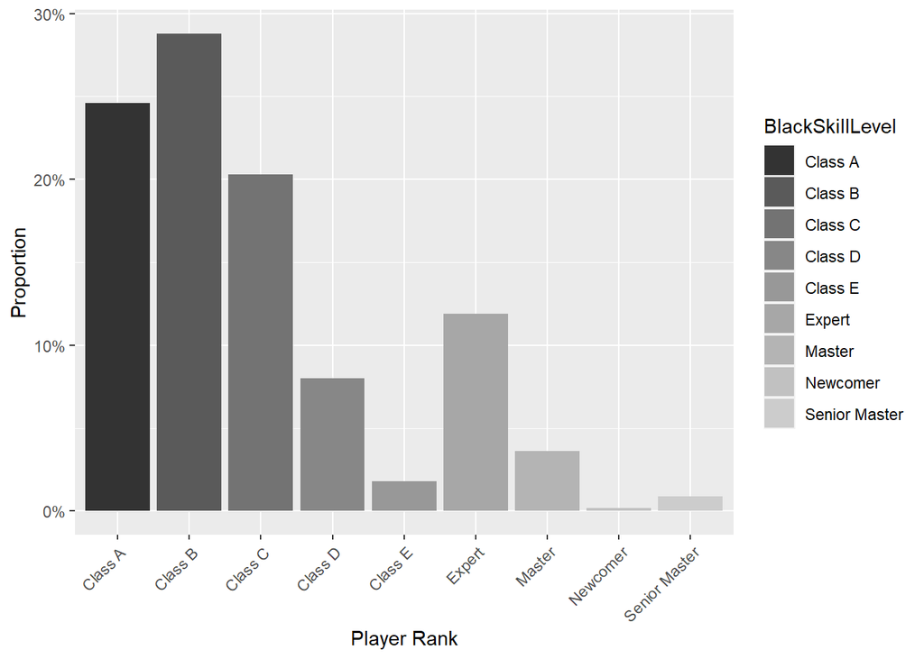

```r
chessGamesSKB <- chessGames2 %>% mutate(BlackSkillLevel = skillCheckBlack1)

 ggplot(chessGamesSKB, aes(x = BlackSkillLevel, fill = BlackSkillLevel)) +
        geom_bar(aes(y = (..count..)/sum(..count..))) +
        xlab("Player Rank") +
        scale_y_continuous(labels = scales::percent, name = "Proportion") +
        theme(axis.text.x = element_text(angle = 45, hjust = 1))+scale_fill_grey()
```

# Statistical techniques

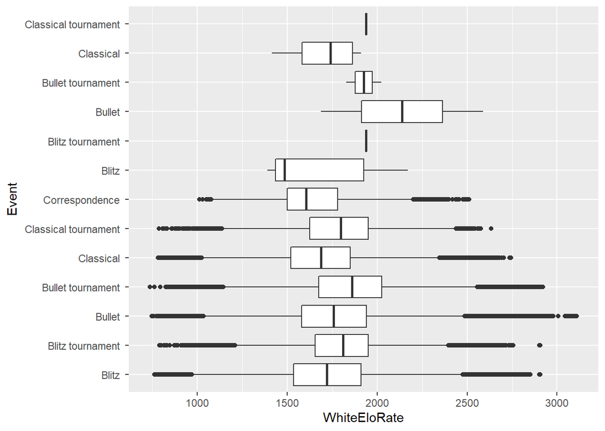

```r
ggp1 <- ggplot(chessGames2, aes(x = Event, y = WhiteEloRate)) +
        geom_boxplot() +
        coord_flip()
ggp2 <- ggplot(chessGames2, aes(x = Event, y = BlackEloRate)) +
        geom_boxplot() +
        coord_flip()
ggp1
```

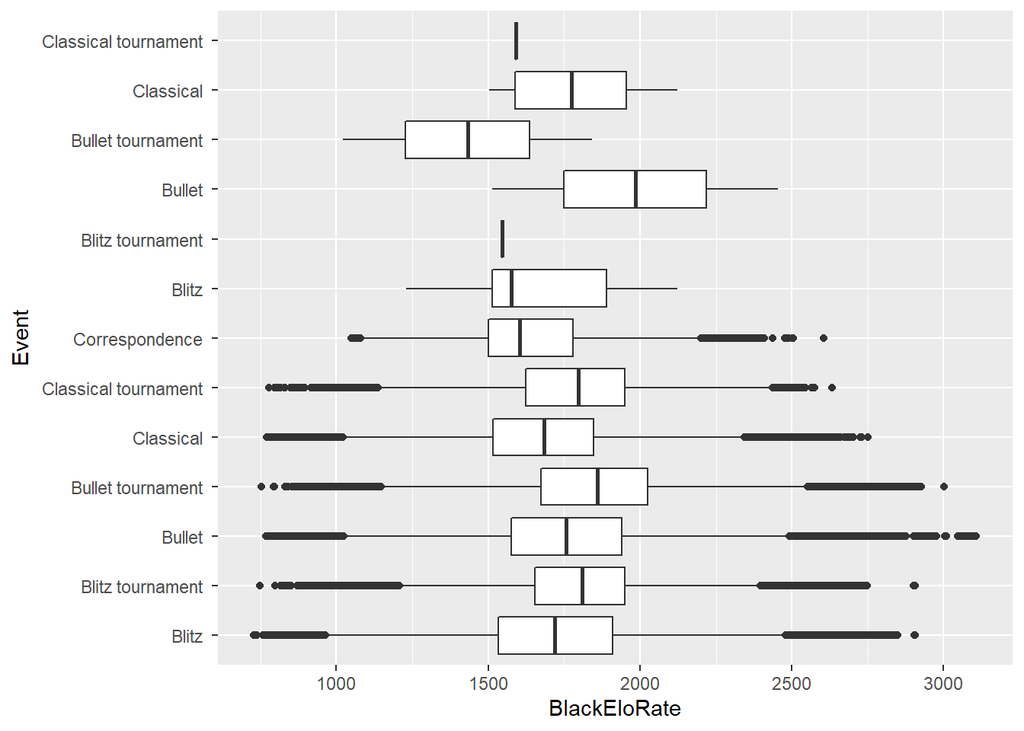

```r
ggp2
```

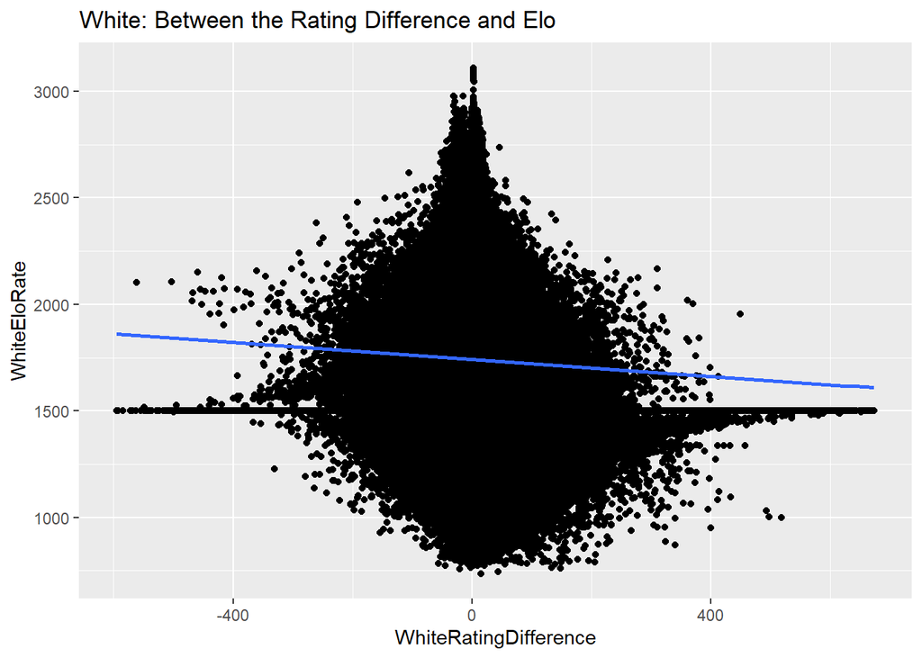

```r
qplot(x = WhiteRatingDifference, y = WhiteEloRate, data = chessGames2, colour = I("black")) +
        geom_smooth(method = "lm", se = FALSE) +
        ggtitle("White: Between the Rating Difference and Elo")
```

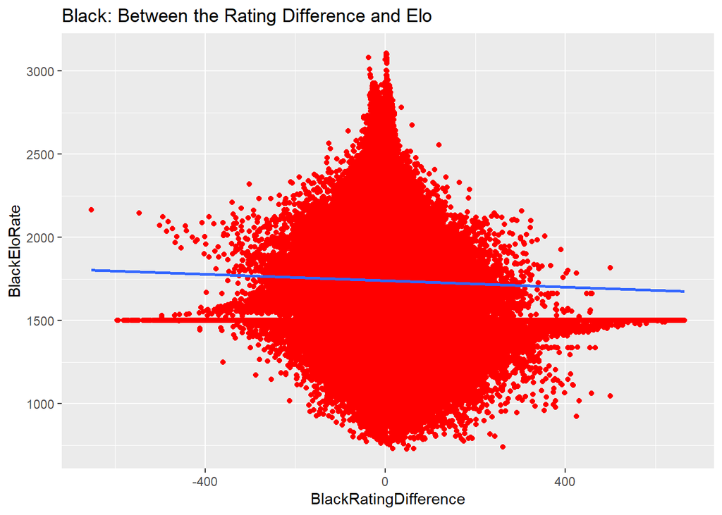

```r
qplot(x = BlackRatingDifference, y = BlackEloRate, data = chessGames2, colour = I("red")) +
        geom_smooth(method = "lm", se = FALSE) +
        ggtitle("Black: Between the Rating Difference and Elo")
```

```r
chessGames3 <- chessGames2 %>% mutate(newTermination = as.factor(ifelse(Termination == "Normal", "Normal", "Penalty")))
chessGamesExpW <- chessGames2 %>% mutate(ExpertOrNot = as.factor(ifelse(WhiteEloRate >= 2200, "Expert", "Amateur")))
chessGamesExpB <- chessGames2 %>% mutate(ExpertOrNot = as.factor(ifelse(WhiteEloRate >= 2200, "Expert", "Amateur")))
```

```r
set.seed(88)
split <- sample.split(chessGames3$newTermination, SplitRatio = 0.00001)

cglTrain <- subset(chessGames3, split == TRUE)

chessGameLog <- glm(newTermination ~ WhiteRatingDifference+BlackRatingDifference+WhiteEloRate+BlackEloRate, data= cglTrain ,family=binomial)
summary(chessGameLog)
```

```
##
## Call:
## glm(formula = newTermination ~ WhiteRatingDifference + BlackRatingDifference +
##     WhiteEloRate + BlackEloRate, family = binomial, data = cglTrain)
##
## Deviance Residuals:
##     Min       1Q   Median       3Q      Max
## -1.9321  -0.8645  -0.6172   1.1179   2.1216
##
## Coefficients:
##                        Estimate Std. Error z value Pr(>|z|)
## (Intercept)           -3.614947   2.113150  -1.711   0.0871 .
## WhiteRatingDifference -0.009169   0.018608  -0.493   0.6222
## BlackRatingDifference -0.018829   0.026357  -0.714   0.4750
## WhiteEloRate           0.004689   0.002055   2.282   0.0225 *
## BlackEloRate          -0.003097   0.001800  -1.721   0.0853 .
## ---
## Signif. codes:  0 '***' 0.001 '**' 0.01 '*' 0.05 '.' 0.1 ' ' 1
##
## (Dispersion parameter for binomial family taken to be 1)
##
##     Null deviance: 77.971  on 61  degrees of freedom
## Residual deviance: 70.362  on 57  degrees of freedom
## AIC: 80.362
##
## Number of Fisher Scoring iterations: 4
```

```r
predictTrain <- predict(chessGameLog, type = "response")
summary(cglTrain)
```

```
##     Event              White              Black              Result
##  Length:62          Length:62          Length:62          Length:62
##  Class :character   Class :character   Class :character   Class :character
##  Mode  :character   Mode  :character   Mode  :character   Mode  :character
##
##
##
##      Date            WhiteEloRate   BlackEloRate  WhiteRatingDifference
##  Length:62          Min.   :1193   Min.   :1053   Min.   :-74.000
##  Class :character   1st Qu.:1576   1st Qu.:1601   1st Qu.: -8.000
##  Mode  :character   Median :1777   Median :1792   Median : -0.500
##                     Mean   :1749   Mean   :1748   Mean   : -1.306
##                     3rd Qu.:1926   3rd Qu.:1900   3rd Qu.:  9.000
##                     Max.   :2384   Max.   :2426   Max.   : 71.000
##  BlackRatingDifference     ECO              Opening          Termination
##  Min.   :-22.000       Length:62          Length:62          Length:62
##  1st Qu.:-10.000       Class :character   Class :character   Class :character
##  Median : -0.500       Mode  :character   Mode  :character   Mode  :character
##  Mean   :  2.242
##  3rd Qu.:  9.500
##  Max.   : 72.000
##  newTermination
##  Normal :42
##  Penalty:20
##
##
##
##
```

```r
length(predictTrain)
```

```
## [1] 62
```

```r
length(cglTrain$newTermination)
```

```
## [1] 62
```

```r
tapply(predictTrain, cglTrain$newTermination, mean)
```

```
##    Normal   Penalty
## 0.2836534 0.4043279
```

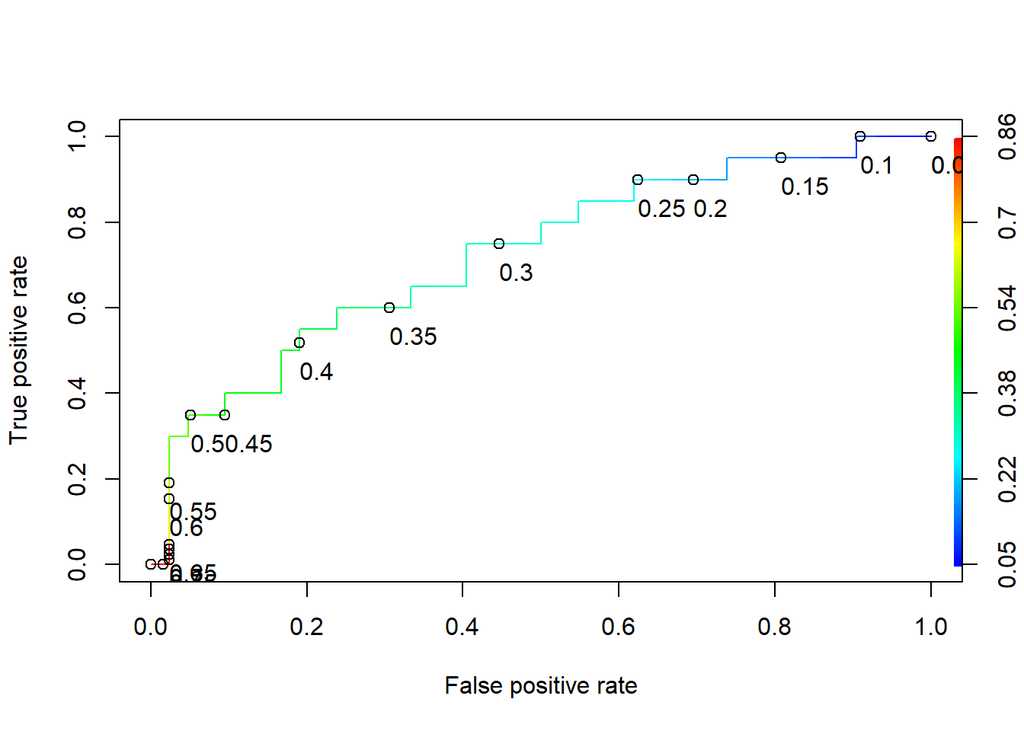

```r
ROCRpredCG = prediction(predictTrain, cglTrain$newTermination)

ROCRperfCG = performance(ROCRpredCG, "tpr", "fpr")

plot(ROCRperfCG, colorize = TRUE, print.cutoffs.at=seq(0,05,by=0.05), text.adj=c(0,2.0))
```

```r
set.seed(88)
splitExpB <- sample.split(chessGamesExpB$ExpertOrNot, SplitRatio = 0.0001)

cglTrainExpB <- subset(chessGamesExpB, splitExpB == TRUE)

chessGameLogExpB <- glm(ExpertOrNot ~ BlackRatingDifference+BlackEloRate, data= cglTrainExpB ,family=binomial)
summary(chessGameLogExpB)
```

```
##
## Call:
## glm(formula = ExpertOrNot ~ BlackRatingDifference + BlackEloRate,
##     family = binomial, data = cglTrainExpB)
##
## Deviance Residuals:
##     Min       1Q   Median       3Q      Max
## -1.2161  -0.2373  -0.1218  -0.0514   3.3518
##
## Coefficients:
##                         Estimate Std. Error z value Pr(>|z|)
## (Intercept)           -18.813923   2.538805  -7.411 1.26e-13 ***
## BlackRatingDifference  -0.009697   0.018174  -0.534    0.594
## BlackEloRate            0.008179   0.001230   6.650 2.94e-11 ***
## ---
## Signif. codes:  0 '***' 0.001 '**' 0.01 '*' 0.05 '.' 0.1 ' ' 1
##
## (Dispersion parameter for binomial family taken to be 1)
##
##     Null deviance: 228.73  on 625  degrees of freedom
## Residual deviance: 149.10  on 623  degrees of freedom
## AIC: 155.1
##
## Number of Fisher Scoring iterations: 7
```

```r
predictTrainExpB <- predict(chessGameLogExpB, type = "response")
summary(cglTrainExpB)
```

```
##     Event              White              Black              Result
##  Length:626         Length:626         Length:626         Length:626
##  Class :character   Class :character   Class :character   Class :character
##  Mode  :character   Mode  :character   Mode  :character   Mode  :character
##
##
##
##      Date            WhiteEloRate   BlackEloRate  WhiteRatingDifference
##  Length:626         Min.   :1072   Min.   : 990   Min.   :-91.0000
##  Class :character   1st Qu.:1548   1st Qu.:1532   1st Qu.: -9.0000
##  Mode  :character   Median :1723   Median :1724   Median :  1.0000
##                     Mean   :1726   Mean   :1717   Mean   :  0.6837
##                     3rd Qu.:1891   3rd Qu.:1901   3rd Qu.:  9.0000
##                     Max.   :2661   Max.   :2645   Max.   :296.0000
##  BlackRatingDifference     ECO              Opening          Termination
##  Min.   :-148.0000     Length:626         Length:626         Length:626
##  1st Qu.:  -9.0000     Class :character   Class :character   Class :character
##  Median :  -1.0000     Mode  :character   Mode  :character   Mode  :character
##  Mean   :   0.1262
##  3rd Qu.:   9.0000
##  Max.   : 266.0000
##   ExpertOrNot
##  Amateur:598
##  Expert : 28
##
##
##
##
```

```r
tapply(predictTrainExpB, cglTrainExpB$ExpertOrNot, mean)
```

```
##    Amateur     Expert
## 0.03283763 0.29868212
```

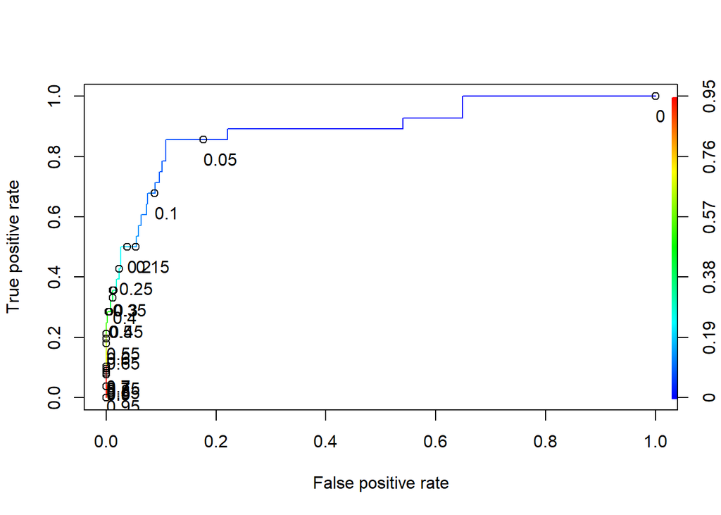

```r
ROCRpredExpB = prediction(predictTrainExpB, cglTrainExpB$ExpertOrNot)

ROCRperfExpB = performance(ROCRpredExpB, "tpr", "fpr")

plot(ROCRperfExpB, colorize = TRUE, print.cutoffs.at=seq(0,05,by=0.05), text.adj=c(0,2.0))
```

```r
set.seed(102)
splitExpW <- sample.split(chessGamesExpW$ExpertOrNot, SplitRatio = 0.0001)

cglTrainExpW <- subset(chessGamesExpW, splitExpW == TRUE)

chessGameLogExpW <- glm(ExpertOrNot ~ WhiteRatingDifference+WhiteEloRate, data= cglTrainExpW ,family=binomial)
summary(chessGameLogExpW)
```

```
##
## Call:
## glm(formula = ExpertOrNot ~ WhiteRatingDifference + WhiteEloRate,
##     family = binomial, data = cglTrainExpW)
##
## Deviance Residuals:
##        Min          1Q      Median          3Q         Max
## -1.331e-03  -2.000e-08  -2.000e-08  -2.000e-08   9.239e-04
##
## Coefficients:
##                         Estimate Std. Error z value Pr(>|z|)
## (Intercept)           -5.910e+03  1.915e+05  -0.031    0.975
## WhiteRatingDifference -8.982e-01  6.969e+01  -0.013    0.990
## WhiteEloRate           2.685e+00  8.700e+01   0.031    0.975
##
## (Dispersion parameter for binomial family taken to be 1)
##
##     Null deviance: 2.2873e+02  on 625  degrees of freedom
## Residual deviance: 3.4218e-06  on 623  degrees of freedom
## AIC: 6
##
## Number of Fisher Scoring iterations: 25
```

```r
predictTrainExpW <- predict(chessGameLogExpW, type = "response")
summary(cglTrainExpW)
```

```
##     Event              White              Black              Result
##  Length:626         Length:626         Length:626         Length:626
##  Class :character   Class :character   Class :character   Class :character
##  Mode  :character   Mode  :character   Mode  :character   Mode  :character
##
##
##
##      Date            WhiteEloRate   BlackEloRate  WhiteRatingDifference
##  Length:626         Min.   :1023   Min.   :1084   Min.   :-306.0000
##  Class :character   1st Qu.:1551   1st Qu.:1564   1st Qu.:  -9.0000
##  Mode  :character   Median :1729   Median :1734   Median :   1.0000
##                     Mean   :1735   Mean   :1741   Mean   :   0.4617
##                     3rd Qu.:1916   3rd Qu.:1896   3rd Qu.:  10.0000
##                     Max.   :2692   Max.   :2541   Max.   : 198.0000
##  BlackRatingDifference     ECO              Opening          Termination
##  Min.   :-196.00000    Length:626         Length:626         Length:626
##  1st Qu.: -10.00000    Class :character   Class :character   Class :character
##  Median :  -1.00000    Mode  :character   Mode  :character   Mode  :character
##  Mean   :   0.05911
##  3rd Qu.:   9.00000
##  Max.   : 174.00000
##   ExpertOrNot
##  Amateur:598
##  Expert : 28
##
##
##
##
```

```r
tapply(predictTrainExpW, cglTrainExpW$ExpertOrNot, mean)
```

```
##      Amateur       Expert
## 1.481187e-09 1.000000e+00
```

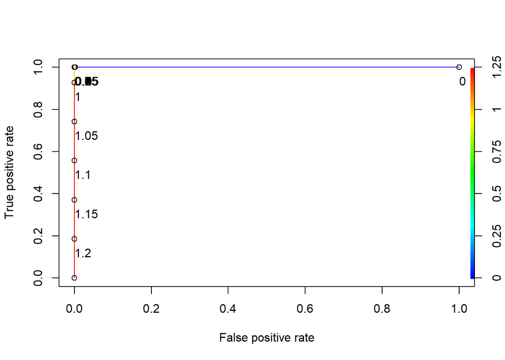

```r
ROCRpredExpW = prediction(predictTrainExpW, cglTrainExpW$ExpertOrNot)

ROCRperfExpW = performance(ROCRpredExpW, "tpr", "fpr")

plot(ROCRperfExpW, colorize = TRUE, print.cutoffs.at=seq(0,05,by=0.05), text.adj=c(0,2.0))
```

[output not shown]